### Проверка соответствия эмпирического распределения нормальному закону

#### **Enginesize**

```r
pander(paste('Коэффициент асимметрии: As = ', round(Skew(df$enginesize), 3)))
```

Коэффициент асимметрии: As = 1.919

```r
pander(paste('Коэффициент эксцесса: Ek = ', round(Kurt(df$enginesize), 3)))
```

Коэффициент эксцесса: Ek = 5.069

Коэффициент асимметрии положителен, по модулю превышает 0.5, следовательно, имеет место сильная правосторонняя асимметрия. Коэффициент эксцесса положителен, что свидетельствует о островершинности распределения. Это противоречит гипотезе о нормальном распределении.

Приступим к визуализации (histogram):

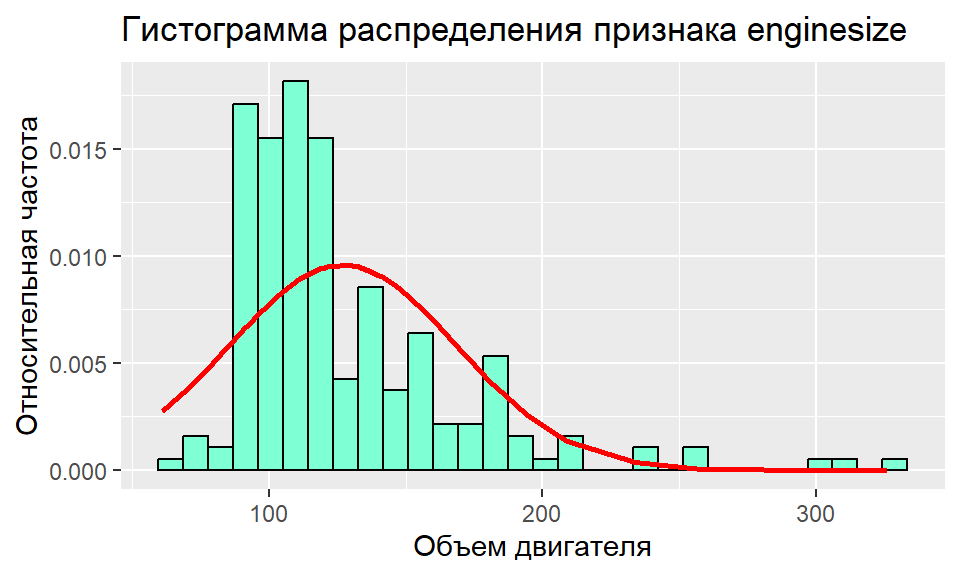

```r
ggplot(df, aes(x = df$enginesize)) + labs(title = 'Гистограмма распределения признака enginesize') +
  geom_histogram(aes(y=..density..),
                 color = "black", fill = "aquamarine") +
  geom_line(aes(x = df$enginesize, y = dnorm(df$enginesize, mean = mean(df$enginesize),
                                            sd = sd(df$enginesize))), lwd = 1, col = 'red') +
  ylab("Относительная частота") +
  xlab("Объем двигателя")
```

График распределения переменной “объем двигателя” не соответствует графику плотности нормального распределения, что противоречит гипотезе о нормальном распределении.

**Dotplot:**

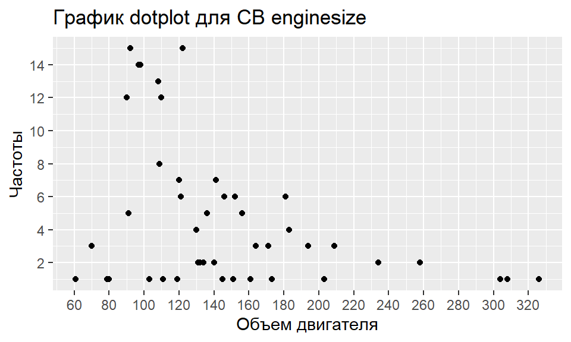

```r
carengine_dot <- ggplot(data = dotplot4) + geom_point(mapping = aes(x = Var1, Freq)) + scale_x_continuous(breaks = seq(0, 330, 20)) + scale_y_continuous(breaks = seq(0, 18, 2)) + labs(title = 'График dotplot для СВ enginesize') + ylab("Частоты") +
  xlab("Объем двигателя")
carengine_dot
```

#### **Horsepower**

```r
pander(paste('Коэффициент асимметрии: As = ', round(Skew(df$horsepower), 3)))
```

Коэффициент асимметрии: As = 1.385

```r
pander(paste('Коэффициент эксцесса: Ek = ', round(Kurt(df$horsepower), 3)))
```

Коэффициент эксцесса: Ek = 2.535

Коэффициент асимметрии положителен, по модулю превышает 0.5, следовательно, имеет место сильная правосторонняя асимметрия. Коэффициент эксцесса положителен, что свидетельствует об островершинности распределения. Мы столкнулись с противоречием гипотезе о нормальном распределении.

Выводы по асимметрии, сделанные ранее, подтвердились.

Приступим к визуализации (histogram):

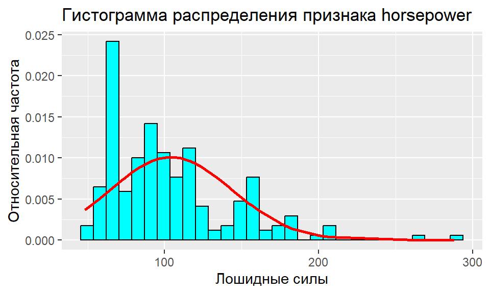

```r
ggplot(df, aes(x = df$horsepower)) + labs(title = 'Гистограмма распределения признака horsepower') +
  geom_histogram(aes(y=..density..),
                 color = "black", fill = "cyan") +
  geom_line(aes(x = df$horsepower, y = dnorm(df$horsepower, mean = mean(df$horsepower),
                                            sd = sd(df$horsepower))), lwd = 1, col = 'red') +
  ylab("Относительная частота") +
  xlab("Лошидные силы")
```

На графике видно, что наша переменная имеет значительный коэффициент эксцесса и правостороннюю асимметрию. Распределение нашей переменной далеко от нормального.

Dotplot:

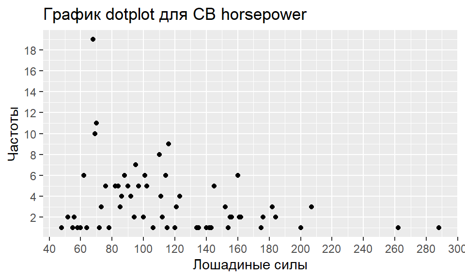

```r
carhp_dot <- ggplot(data = dotplot5) + geom_point(mapping = aes(x = Var1, Freq)) + scale_x_continuous(breaks = seq(0, 300, 20)) + scale_y_continuous(breaks = seq(0, 20, 2)) + labs(title = 'График dotplot для СВ horsepower') + ylab("Частоты") +
  xlab("Лошадиные силы")
carhp_dot
```

По точечной диаграмме переменной horsepower (лошадиные силы) мы видим большой пробел в данных, после которого идут 2 наблюдений, далеких от общей массы. Из-за этого большая часть наблюдений сконцентрирована в левой части диаграммы. Модальное значение равно 68 (встречается 19 раз).

#### **Peakrpm**

```r
pander(paste('Коэффициент асимметрии: As = ', round(Skew(df$peakrpm), 3)))
```

Коэффициент асимметрии: As = 0.074

```r
pander(paste('Коэффициент эксцесса: Ek = ', round(Kurt(df$peakrpm), 3)))
```

Коэффициент эксцесса: Ek = 0.026

Коэффициент асимметрии положителен, по модулю не превышает 0.5, потому асимметрия не значительна. Коэффициент эксцесса положителен и едва ли отличается от 0.

Приступим к визуализации (histogram):

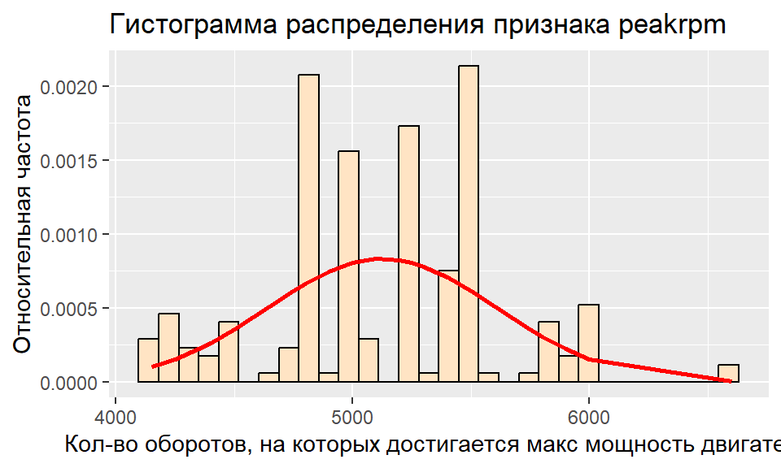

```r
ggplot(df, aes(x = df$peakrpm)) + labs(title = 'Гистограмма распределения признака peakrpm') +
  geom_histogram(aes(y=..density..),
                 color = "black", fill = "bisque1") +
  geom_line(aes(x = df$peakrpm, y = dnorm(df$peakrpm, mean = mean(df$peakrpm),
                                            sd = sd(df$peakrpm))), lwd = 1, col = 'red') +
  ylab("Относительная частота") +
  xlab("Кол-во оборотов, на которых достигается макс мощность двигателя")
```

Dotplot:

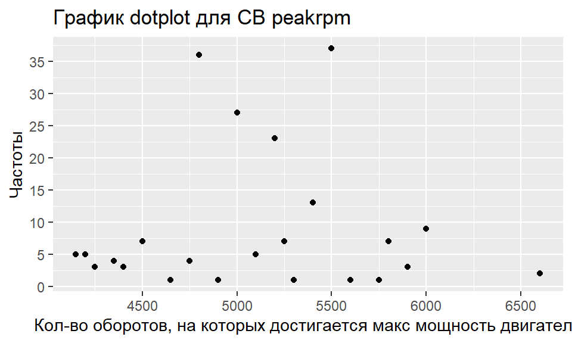

```r
carrpm_dot <- ggplot(data = dotplot6) + geom_point(mapping = aes(x = Var1, Freq)) + scale_x_continuous(breaks = seq(0, 7000, 500)) + scale_y_continuous(breaks = seq(0, 40, 5)) + labs(title = 'График dotplot для СВ peakrpm') + ylab("Частоты") +
  xlab("Кол-во оборотов, на которых достигается макс мощность двигателя")
carrpm_dot
```

На графике для переменной peakrpm (количество оборотов, при которых достигается максимальная мощность двигателя) мы видим меньшее количество точек, чем мы видели на предыдущих графиках, но определенные значения теперь принимаются большее количество раз.  
Это связано с тем, что автопроизводители устанавливают стандартные двигатели, поэтому многие машины достигают максимальной мощности двигателя при количестве оборотов равных 4800 (36 автомобилей), 5000 (27 автомобилей) и модальном значении - 5500 (37 автомобилей).

### **Проверка гипотезы о нормальном распределении совокупности с использованием статистического критерия (критерий Пирсона, Колмогорова)**

Для проверки соответствия эмпирического распределения некоторому теоретическому используют критерии согласия. Нас интересует проверка следующей гипотезы:

$$H_0 : \text{ выборка взята из генеральной совокупности с нормальным
распределением }$$

#### **Tests for enginesize**

*Критерий согласия Пирсона:*

```r
pander(PearsonTest(df$enginesize))
```

Pearson chi-square normality test: `df$enginesize`

| Test statistic | P value |
| --- | --- |
| 185 | 6.238e-32 * * * |

Нулевая гипотеза отвергается с вероятностью ошибки 0,05. Следовательно, мы не можем утверждать, что выборка взята из генеральной совокупности с нормальным распределением, такой же вывод мы сделали исходя из графика.

*Критерий Шапиро-Уилка:*

```r
pander(shapiro.test(df$enginesize))
```

Shapiro-Wilk normality test: `df$enginesize`

| Test statistic | P value |
| --- | --- |
| 0.8294 | 3.057e-14 * * * |

Здесь также получаем p-value значительно меньше 0,05, следовательно, по критерию Шапиро-Уилка нулевая гипотеза о нормальности распределения случайной величины **`enginesize`** отвергается с вероятностью ошибки 0,05.

*Тест Колмогорова-Смирнова:*

```r
pander(ks.test(df$enginesize, 'pnorm', mean(df$enginesize), sd(df$enginesize)))
```

Asymptotic one-sample Kolmogorov-Smirnov test: `df$enginesize`

| Test statistic | P value | Alternative hypothesis |
| --- | --- | --- |
| 0.1811 | 2.913e-06 * * * | two-sided |

P-value мало, меньше любого разумного уровня значимости. Следовательно, нулевая гипотеза о нормальности распределения отвергается с вероятностью ошибки 0,05.

Таким образом, по результатом трех тестов мы можем сказать, что случайная величина **`enginesize`** **не подчиняется нормальному закону распределения**.

#### **Tests for horsepower**

*Критерий согласия Пирсона:*

```r
pander(PearsonTest(df$horsepower))
```

Pearson chi-square normality test: `df$horsepower`

| Test statistic | P value |
| --- | --- |
| 136.7 | 3.148e-22 * * * |

Нулевая гипотеза отвергается с вероятностью ошибки 0,05. Следовательно, мы не можем утверждать, что выборка взята из генеральной совокупности с нормальным распределением, такой же вывод мы сделали исходя из графика.

*Критерий Шапиро-Уилка:*

```r
pander(shapiro.test(df$horsepower))
```

Shapiro-Wilk normality test: `df$horsepower`

| Test statistic | P value |
| --- | --- |
| 0.8836 | 1.736e-11 * * * |

Здесь также получаем p-value значительно меньше 0,05, следовательно, по критерию Шапиро-Уилка нулевая гипотеза о нормальности распределения генеральной совокупности случайной величины `horsepower`(лошадиные силы (в киловаттах)) отвергается с вероятностью ошибки 0,05.

*Тест Колмогорова-Смирнова:*

```r
pander(ks.test(df$horsepower, 'pnorm', mean(df$horsepower), sd(df$horsepower)))
```

Asymptotic one-sample Kolmogorov-Smirnov test: `df$horsepower`

| Test statistic | P value | Alternative hypothesis |
| --- | --- | --- |
| 0.138 | 0.0008132 * * * | two-sided |

P-value маленькое, меньше любого разумного уровня значимости. Следовательно, нулевая гипотеза о нормальности распределения отвергается с вероятностью ошибки 0,05.

Таким образом, на основе результатов трех тестов мы можем сказать, что случайная величина `horsepower`(лошадиные силы (в киловаттах)) **не подчиняется нормальному закону распределения.**

#### **Tests for peakrpm**

*Критерий согласия Пирсона:*

```r
pander(PearsonTest(df$peakrpm))
```

Pearson chi-square normality test: `df$peakrpm`

| Test statistic | P value |
| --- | --- |
| 197.1 | 2.135e-34 * * * |

Нулевая гипотеза отвергается с вероятностью ошибки 0,05. Следовательно, мы не можем утверждать, что выборка взята из генеральной совокупности с нормальным распределением.

*Критерий Шапиро-Уилка:*

```r
pander(shapiro.test(df$peakrpm))
```

Shapiro-Wilk normality test: `df$peakrpm`

| Test statistic | P value |
| --- | --- |
| 0.9705 | 0.0002684 * * * |

*Тест Колмогорова-Смирнова:*

```r
pander(ks.test(df$peakrpm, 'pnorm', mean(df$peakrpm), sd(df$peakrpm)))
```

Asymptotic one-sample Kolmogorov-Smirnov test: `df$peakrpm`

| Test statistic | P value | Alternative hypothesis |
| --- | --- | --- |
| 0.1038 | 0.02421 * | two-sided |

P-value = 0.0242, что меньше заданного уровня значимости. Так, нулевая гипотеза о нормальности распределения отвергается с вероятностью ошибки 0,05.

Таким образом, на основе результатов трех тестов мы можем сказать, что случайная величина `peakrpm` не подчиняется нормальному закону распределения.

### **Основные характеристики (citympg, highwaympg)**

Продолжим предварительный анализ переменных. Рассмотрим следующую категорию признаков *“Расход топлива”*:

#### **Анализ citympg**

*Характеристики положения СВ:*

```r
pander(paste('Среднее: ', round(mean(df$citympg), 3)))
```

Среднее: 25.22

```r
pander(paste('Медиана: ', median(df$citympg)))
```

Медиана: 24

```r
pander(paste('Мода: ', Mode(df$citympg)))
```

Мода: 31

Для переменной `citympg`(мили на галлон топлива, потребляемого при движении по городу) значение моды, медианы и среднего далеки друг от друга, что опять же свидетельствует о том, что мы столкнулись с противоречием к гипотезе о нормальном законе распределения.

*Характеристики разброса СВ:*

```r
ch_var7 <- data.frame('Статистика' =
                       c('Min', 'Max', 'Размах: R',
                         'Дисперсия', 'Std dev',
                         'IQR', 'Coef var, %'),
                     'Значение' = c(range(df$citympg)[1],
                                    range(df$citympg)[2],
                                    round(range(df$citympg)[2] - range(df$citympg)[1], 3),
                     round(var(df$citympg), 3),
                     round(sd(df$citympg), 3),
                     IQR(df$citympg),
                     round(CoefVar(df$citympg)*100, 2)))

pander(ch_var7)
```

| Статистика | Значение |
| --- | --- |
| Min | 13 |
| Max | 49 |
| Размах: R | 36 |
| Дисперсия | 42.8 |
| Std dev | 6.542 |
| IQR | 11 |
| Coef var, % | 25.94 |

Значение коэффициента вариации не превышает 33%. Это говорит нам об однородности переменной `citympg`(мили на галлон топлива, потребляемого при движении по городу).

*Ранговые характеристики СВ:*

```r
pander(summary(df$citympg))
```

| Min. | 1st Qu. | Median | Mean | 3rd Qu. | Max. |
| --- | --- | --- | --- | --- | --- |
| 13 | 19 | 24 | 25.22 | 30 | 49 |

```r
pander(quantile(df$citympg))
```

| 0% | 25% | 50% | 75% | 100% |
| --- | --- | --- | --- | --- |
| 13 | 19 | 24 | 30 | 49 |

Для случайной величины `citympg`(мили на галлон топлива, потребляемого при движении по городу) мы получили: Q1 = 19; Q3 = 30. Следовательно, 25% выборки принимает значения меньше 19; 25% выборки принимают значения больше 30.

```r
pander(quantile(df$citympg, probs = seq(0, 1, 0.1)))
```

| 0% | 10% | 20% | 30% | 40% | 50% | 60% | 70% | 80% | 90% | 100% |
| --- | --- | --- | --- | --- | --- | --- | --- | --- | --- | --- |
| 13 | 17 | 19 | 21 | 23.6 | 24 | 26 | 28 | 31 | 31.6 | 49 |

Для этой случайной величины мы также нашли децили. Медиана равна 24, то есть половины значений выборки принимают значения меньше 24, а другая половина больше. Минимальное значение - 13; Максимальное - 49. Опять можно говорить о правосторонней асимметрии, т.к. правее медианы находится больше значений (разница между максимальным значением и медианой больше), чем левее.

#### **Анализ highwaympg**

*Характеристики положения СВ:*

```r
pander(paste('Среднее: ', round(mean(df$highwaympg), 3)))
```

Среднее: 30.751

```r
pander(paste('Медиана: ', median(df$highwaympg)))
```

Медиана: 30

```r
pander(paste('Мода: ', Mode(df$highwaympg)))
```

Мода: 25

Необходимо заметить, что полученные значения среднего и медианы приблизительно равны. Однако они заметно отличаются от медианы. Это позволяет нам сделать предположение о том, что переменная `highwaympg` (мили на галлон топлива, потребляемого при движении по шоссе) не соответствует нормальному закону распределения.

*Характеристики разброса СВ:*

```r
ch_var8 <- data.frame('Статистика' =
                       c('Min', 'Max', 'Размах: R',
                         'Дисперсия', 'Std dev',
                         'IQR', 'Coef var, %'),
                     'Значение' = c(range(df$highwaympg)[1],
                                    range(df$highwaympg)[2],
                                    round(range(df$highwaympg)[2] - range(df$highwaympg)[1], 3),
                     round(var(df$highwaympg), 3),
                     round(sd(df$highwaympg), 3),
                     IQR(df$highwaympg),
                     round(CoefVar(df$highwaympg)*100, 2)))

pander(ch_var8)
```

| Статистика | Значение |
| --- | --- |
| Min | 16 |
| Max | 54 |
| Размах: R | 38 |
| Дисперсия | 47.42 |
| Std dev | 6.886 |
| IQR | 9 |
| Coef var, % | 22.39 |

Значение коэффициента вариации меньше 33%, что может свидетельствовать об однородности переменной `highwaympg`(мили на галлон топлива, потребляемого при движении по шоссе).

*Ранговые характеристики СВ:*

```r
pander(summary(df$highwaympg))
```

| Min. | 1st Qu. | Median | Mean | 3rd Qu. | Max. |
| --- | --- | --- | --- | --- | --- |
| 16 | 25 | 30 | 30.75 | 34 | 54 |

```r
pander(quantile(df$highwaympg))
```

| 0% | 25% | 50% | 75% | 100% |
| --- | --- | --- | --- | --- |
| 16 | 25 | 30 | 34 | 54 |

```r
pander(quantile(df$highwaympg, probs = seq(0, 1, 0.1)))
```

| 0% | 10% | 20% | 30% | 40% | 50% | 60% | 70% | 80% | 90% | 100% |
| --- | --- | --- | --- | --- | --- | --- | --- | --- | --- | --- |
| 16 | 23 | 24.8 | 26 | 29 | 30 | 32 | 34 | 37 | 38 | 54 |

Аналогичные выводы можно сделать и по децилям. Например, 10% выборки принимают значения меньше 23, а 90% выборки принимают значения больше 23. Можно заметить, что разница между медианной и минимальным значением значительно меньше, чем разница между максимальным значением и медианой, что может свидетельствовать о правосторонней асимметрии.

### **Диагностика выбросов (citympg, highwaympg)**

#### **Анализ citympg**

*Расчет межквартильной разницы СВ:*

```r
paste('Межквартильный размах: IQR = Q3 - Q1 = ', round(IQR(df$citympg), 3))
```

```
## [1] "Межквартильный размах: IQR = Q3 - Q1 =  11"
```

*Найдем значения, выходящие за пределы 1,5IQR:*

```r
out_of_1.5IQR7 <- boxplot.stats(df$citympg)$out
out_of_1.5IQR7
```

```
## [1] 47 49
```

Получаем два выброса - 47, 49.

*Применим правило 3IQR:*

```r
out_of_3IQR7 <- boxplot.stats(df$citympg, coef = 3)$out
out_of_3IQR7
```

```
## numeric(0)
```

По правилу 3IQR нет выбросов.

*Правило 3-х сигм:*

```r
paste('3σ = ', round(3*sd(df$citympg), 3))
```

```
## [1] "3σ =  19.626"
```

```r
paste('Среднее: ', round(mean(df$citympg), 3))
```

```
## [1] "Среднее:  25.22"
```

$$P(|x-25.22| < 19.626)= 0,9973$$

$$P(5,594 < x < 44,846)= 0,9973$$

С вероятностью 0,9973 значения величины `citympg`(мили на галлон топлива, потребляемого при движении по городу) лежат в интервале от 5,594 до 44,846. Следовательно, согласно правилу трех сигм у нас 3 выброса: 45, 47, 49.

*Построим ящичковую диаграмму для данной СВ:*

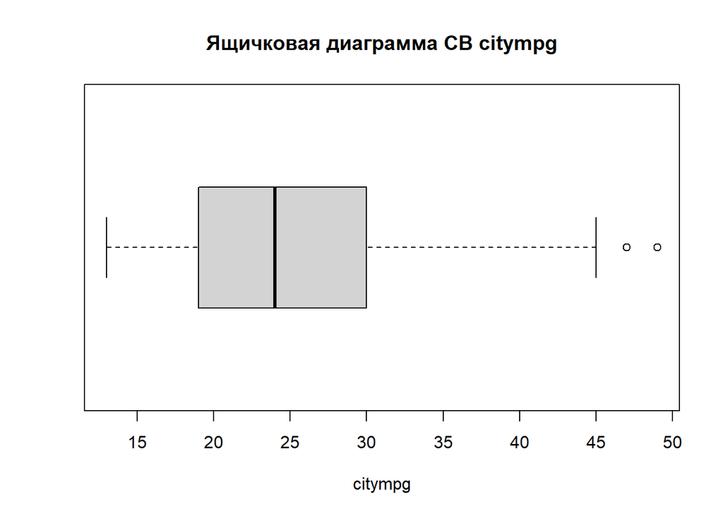

```r
boxplot(df$citympg, horizontal = TRUE, xlab = 'citympg', main = 'Ящичковая диаграмма СВ citympg')
```

На графике мы видим два выброса, выходящие за пределы правила 1,5IQR. Его значение мы нашли выше. Медиана равна 24 и находится ближе к значению первого квартиля (смещена влево в прямоугольнике, показывающем межквартильный диапазон). Первый квартиль принимает значение 19 , третий - 30.

*Проведем тест Граббса для данной СВ:*

```r
grubbs.test(df$citympg)
```

```
##
##  Grubbs test for one outlier
##
## data:  df$citympg
## G = 3.63497, U = 0.93491, p-value = 0.02283
## alternative hypothesis: highest value 49 is an outlier
```

```r
grubbs.test(df$citympg, opposite = TRUE)
```

```
##
##  Grubbs test for one outlier
##
## data:  df$citympg
## G = 1.86782, U = 0.98281, p-value = 1
## alternative hypothesis: lowest value 13 is an outlier
```

#### **Анализ highwaympg**

*Расчет межквартильной разницы СВ:*

```r
paste('Межквартильный размах: IQR = Q3 - Q1 = ', round(IQR(df$highwaympg), 3))
```

```
## [1] "Межквартильный размах: IQR = Q3 - Q1 =  9"
```

*Найдем значения, выходящие за пределы 1,5IQR:*

```r
out_of_1.5IQR8 <- boxplot.stats(df$highwaympg)$out
out_of_1.5IQR8
```

```
## [1] 53 54 50
```

Мы получили 3 выброса. Они принимают значения: 50, 53 и 54 миль на галлон топлива.

*Применим правило 3IQR:*

```r
out_of_3IQR8 <- boxplot.stats(df$highwaympg, coef = 3)$out
out_of_3IQR8
```

```
## numeric(0)
```

По правилу 3IQR выбросов нет.

*Правило 3-х сигм:*

```r
paste('3σ = ', round(3*sd(df$highwaympg), 3))
```

```
## [1] "3σ =  20.659"
```

```r
paste('Среднее: ', round(mean(df$highwaympg), 3))
```

```
## [1] "Среднее:  30.751"
```

$$P(|x-30,751| < 20,659)= 0,9973$$

*Построим ящичковую диаграмму для данной СВ:*

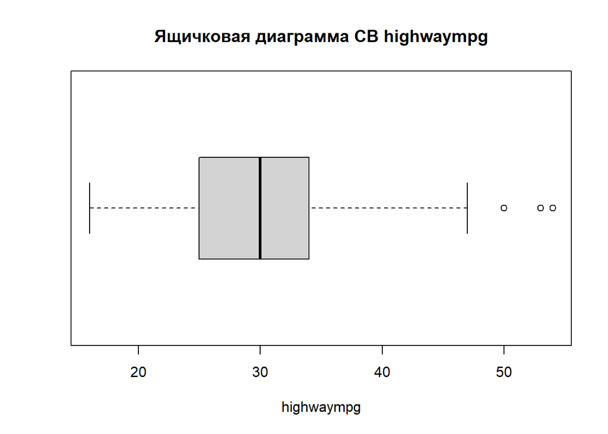

```r
boxplot(df$highwaympg, horizontal = TRUE, xlab = 'highwaympg', main = 'Ящичковая диаграмма СВ highwaympg')
```

*Проведем тест Граббса для данной СВ:*

```r
grubbs.test(df$highwaympg)
```

```
##
##  Grubbs test for one outlier
##
## data:  df$highwaympg
## G = 3.37602, U = 0.94386, p-value = 0.06403
## alternative hypothesis: highest value 54 is an outlier
```

Мы получили значение p-value = 0,06403. Так как это значение больше 0,05, то на уровне значимости 5% мы принимаем нулевую гипотезу о том, что максимальное значение, равное 54, является типичным наблюдением.

```r
grubbs.test(df$highwaympg, opposite = TRUE)
```

```
##
##  Grubbs test for one outlier
##
## data:  df$highwaympg
## G = 2.1421, U = 0.9774, p-value = 1
## alternative hypothesis: lowest value 16 is an outlier
```

### **Основные характеристики (wheelbase, curbweight)**

Продолжим предварительный анализ переменных. Рассмотрим следующую категорию признаков *“Прочее”*:

#### **Анализ wheelbase**

*Характеристики положения СВ:*

```r
pander(paste('Среднее: ', round(mean(df$wheelbase), 3)))
```

Среднее: 98.757

```r
pander(paste('Медиана: ', median(df$wheelbase)))
```

Медиана: 97

```r
pander(paste('Мода: ', Mode(df$wheelbase)))
```

Мода: 94.5

Необходимо заметить, что полученные значения среднего, медианы и моды не равны, значительно отличаются друг от друга. Это позволяет нам сделать предположение о том, что переменная “расстояние между передним и задним колесами” не соответствует нормальному закону распределения.

*Характеристики разброса СВ:*

```r
ch_var9 <- data.frame('Статистика' =
                       c('Min', 'Max', 'Размах: R',
                         'Дисперсия', 'Std dev',
                         'IQR', 'Coef var, %'),
                     'Значение' = c(range(df$wheelbase)[1],
                                    range(df$wheelbase)[2],
                                    round(range(df$wheelbase)[2] - range(df$wheelbase)[1], 3),
                     round(var(df$wheelbase), 3),
                     round(sd(df$wheelbase), 3),
                     IQR(df$wheelbase),
                     round(CoefVar(df$wheelbase)*100, 2)))

pander(ch_var9)
```

| Статистика | Значение |
| --- | --- |
| Min | 86.6 |
| Max | 120.9 |
| Размах: R | 34.3 |
| Дисперсия | 36.26 |
| Std dev | 6.022 |
| IQR | 7.9 |
| Coef var, % | 6.1 |

Значение коэффициента вариации не превышает 33%. Это говорит нам об однородности переменной “расстояние между передним и задним колесами”.

*Ранговые характеристики СВ:*

```r
pander(summary(df$wheelbase))
```

| Min. | 1st Qu. | Median | Mean | 3rd Qu. | Max. |
| --- | --- | --- | --- | --- | --- |
| 86.6 | 94.5 | 97 | 98.76 | 102.4 | 120.9 |

| 0% | 25% | 50% | 75% | 100% |
| --- | --- | --- | --- | --- |
| 86.6 | 94.5 | 97 | 102.4 | 120.9 |

Для случайной величины “расстояние между передним и задним колесами” мы получили: Q1 = 94,5; Q3 = 102,4. Следовательно, 25% выборки принимает значения меньше 94,5; 25% выборки принимают значения больше 102,4.

| 0% | 10% | 20% | 30% | 40% | 50% | 60% | 70% | 80% | 90% | 100% |
| --- | --- | --- | --- | --- | --- | --- | --- | --- | --- | --- |
| 86.6 | 93.7 | 94.5 | 95.3 | 95.96 | 97 | 98.4 | 100.4 | 103.5 | 107.9 | 120.9 |

Аналогичные выводы можно сделать и по децилям. Так, например, 70% выборки принимают значения меньше 100,4. А 10% выборки принимают значения больше 107,9. Медиана равна 97, то есть половина значений выборки меньше 97, а другая половина больше. Минимальное значение равно 86,6, то есть 0% процентов выборки принимают значение меньше этого. Максимальное - 120,9, 100% выборки принимают значения меньше 120,9.

#### **Анализ curbweight**

*Характеристики положения СВ:*

```r
pander(paste('Среднее: ', round(mean(df$curbweight), 3)))
```

Среднее: 2555.566

```r
pander(paste('Медиана: ', median(df$curbweight)))
```

Медиана: 2414

```r
pander(paste('Мода: ', Mode(df$curbweight)))
```

Мода: 2385

Полученные значения среднего, медианы и моды не равны, значительно отличаются друг от друга. Это позволяет нам сделать предположение о том, что переменная curbweight не соответствует нормальному закону распределения.

*Характеристики разброса СВ:*

```r
ch_var10 <- data.frame('Статистика' =
                       c('Min', 'Max', 'Размах: R',
                         'Дисперсия', 'Std dev',
                         'IQR', 'Coef var, %'),
                     'Значение' = c(range(df$curbweight)[1],
                                    range(df$curbweight)[2],
                                    round(range(df$curbweight)[2] - range(df$curbweight)[1], 3),
                     round(var(df$curbweight), 3),
                     round(sd(df$curbweight), 3),
                     IQR(df$curbweight),
                     round(CoefVar(df$curbweight)*100, 2)))

pander(ch_var10)
```

| Статистика | Значение |
| --- | --- |
| Min | 1488 |
| Max | 4066 |
| Размах: R | 2578 |
| Дисперсия | 271108 |
| Std dev | 520.7 |
| IQR | 790 |
| Coef var, % | 20.37 |

Значение коэффициента вариации не превышает 33%. Это говорит нам об однородности переменной.

*Ранговые характеристики СВ:*

```r
pander(summary(df$curbweight))
```

| Min. | 1st Qu. | Median | Mean | 3rd Qu. | Max. |
| --- | --- | --- | --- | --- | --- |
| 1488 | 2145 | 2414 | 2556 | 2935 | 4066 |

| 0% | 25% | 50% | 75% | 100% |
| --- | --- | --- | --- | --- |
| 1488 | 2145 | 2414 | 2935 | 4066 |

Мы получили: Q1 = 2145; Q3 = 2935. Следовательно, 25% выборки принимает значения меньше 2145; 25% выборки принимают значения больше 2935.

| 0% | 10% | 20% | 30% | 40% | 50% | 60% | 70% | 80% | 90% | 100% |
| --- | --- | --- | --- | --- | --- | --- | --- | --- | --- | --- |
| 1488 | 1947 | 2048 | 2243 | 2333 | 2414 | 2579 | 2817 | 3046 | 3230 | 4066 |

### **Диагностика выбросов (wheelbase, curbweight)**

#### **Анализ wheelbase**

*Расчет межквартильной разницы СВ:*

```r
paste('Межквартильный размах: IQR = Q3 - Q1 = ', round(IQR(df$wheelbase), 3))
```

```
## [1] "Межквартильный размах: IQR = Q3 - Q1 =  7.9"
```

*Найдем значения, выходящие за пределы 1,5IQR:*

```r
out_of_1.5IQR9 <- boxplot.stats(df$wheelbase)$out
out_of_1.5IQR9
```

```
## [1] 115.6 115.6 120.9
```

Мы получили три выброса. Два принимают значение 115,6; один - 120,9.

*Применим правило 3IQR:*

```r
out_of_3IQR9 <- boxplot.stats(df$wheelbase, coef = 3)$out
out_of_3IQR9
```

```
## numeric(0)
```

По правилу 3IQR нет выбросов.

*Правило 3-х сигм:*

```r
paste('3σ = ', round(3*sd(df$wheelbase), 3))
```

```
## [1] "3σ =  18.065"
```

```r
paste('Среднее: ', round(mean(df$wheelbase), 3))
```

```
## [1] "Среднее:  98.757"
```

$$P(|x-98,757| < 18,065)= 0,9973$$

$$P(80,692 < x < 116,822)= 0,9973$$

С вероятностью 0,9973 значения величины “расстояние между передним и задним колесами” лежат в интервале от 80,692 до 116,822. Минимальное значение этой переменной равно 86,6, максимальное значение равно 120,9. Следовательно, согласно правилу трех сигм слева выбросов у нас нет, справа один выброс - 120,9.

*Построим ящичковую диаграмму для данной СВ:*

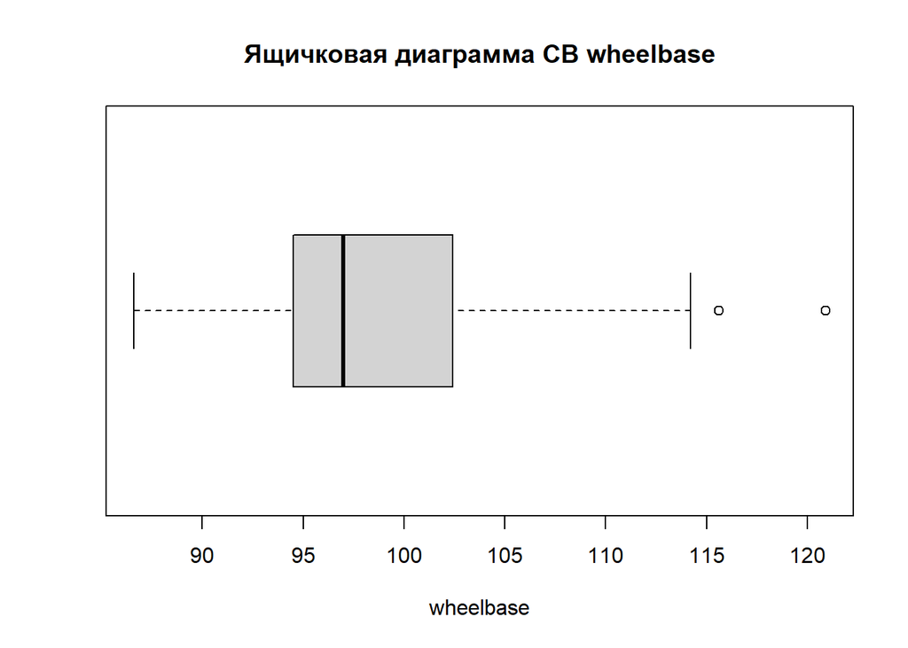

```r
boxplot(df$wheelbase, horizontal = TRUE, xlab = 'wheelbase', main = 'Ящичковая диаграмма СВ wheelbase')
```

На графике два значения выходят за пределы правила 1.5IQR, то есть являются выбросами (выше мы получили, что их 3, два из них равны). Медиана равна 97 и находится ближе к значению первого квартиля (смещена влево в прямоугольнике, показывающем межквартильный диапазон). Первый квартиль немного превышает значение 94, третий около 102.

*Проведем тест Граббса для данной СВ:*

```r
grubbs.test(df$wheelbase)
```

```
##
##  Grubbs test for one outlier
##
## data:  df$wheelbase
## G = 3.67722, U = 0.93339, p-value = 0.01915
## alternative hypothesis: highest value 120.9 is an outlier
```

Мы получили значение p-value = 0,01915. Поскольку это значение меньше 0,05, мы отвергаем нулевую гипотезу и делаем вывод о том, что максимальное значение 120,9 является выбросом.

```r
grubbs.test(df$wheelbase, opposite = TRUE)
```

```
##
##  Grubbs test for one outlier
##
## data:  df$wheelbase
## G = 2.01877, U = 0.97992, p-value = 1
## alternative hypothesis: lowest value 86.6 is an outlier
```

P-value **= 1**. Поскольку это значение не меньше 0,05, мы не можем отвергнуть нулевую гипотезу. У нас нет достаточных доказательств, чтобы сказать, что минимальное значение 86,6 является выбросом.